# Predictive Analytics - Classification

JIA YI HUANG

2026-04-22

## Classification - the target variable is categorical.

## Predictive Analytics - Classification

Predictive analytics in a classification context aims to predict a categorical outcome (e.g., “admitted” or “not admitted”) based on historical data. Unlike regression, which predicts continuous numbers, classification handles discrete classes.

### Key Classification Concepts

- **Logistic Regression**: The standard algorithm for binary classification. It uses a “logit” link function to map predictors to a probability between 0 and 1.
- **The Decision Threshold**: Once the model provides a probability (e.g., 0.65), we must choose a cutoff (threshold) to decide the final class. A common default is 0.5, but this can be tuned based on the cost of errors.
- **Confusion Matrix**: A table used to evaluate performance by comparing actual vs. predicted values, showing True Positives, False Positives, etc.
- **ROC Curve and AUC**:
  - **ROC (Receiver Operating Characteristic)**: A plot of the True Positive Rate vs. the False Positive Rate across various thresholds.
  - **AUC (Area Under the Curve)**: A single metric (0 to 1) representing model quality. An AUC of 1.0 is perfect, while 0.5 is no better than random guessing.

## Logistic Regression Overview

Logistic regression is an effective tool for addressing binary classification problems, such as:

- Predicting whether a specific stock’s value will appreciate during the next trading cycle.
- Determining if a student will be admitted to a university based on standardized evaluation criteria.
- Estimating the probability that an automotive company will launch a new model within the next year.
- Assessing whether a particular stock will issue a dividend payment this year.

In these scenarios, the outcome is discrete (e.g., “Yes” or “No”) rather than a continuous value. For instance, the annual percentage gain on a stock is a continuous metric and would require a standard linear regression rather than a logistic model.

In logistic regression, the relationship between the predictors and the outcome is modeled using an exponential function.

Let *p* represent the probability (likelihood) of a stock exhibiting bullish movement in the next trading cycle. Assume this movement is influenced by three primary factors: $X_1$, $X_2$, and $X_3$. Based on these factors, the model calculates a linear consensus score, *Y*, expressed as:

$$Y = \beta_0 + \beta_1X_1 + \beta_2X_2 +
\beta_3X_3$$

However, since *Y* can range from $-\infty$ to $+\infty$, we cannot directly interpret it as a probability (which must be between 0 and 1). To convert this linear score into a probability, we use the **logistic (sigmoid) function**:

$$p = \frac{1}{1 + e^{-Y}}$$

This transformation ensures that: - When $Y$ is large and positive, $p$ approaches 1. - When $Y$ is large and negative, $p$ approaches 0. - When $Y = 0$, $p = 0.5$, the decision boundary.

The coefficients ($\beta$) are estimated using **maximum likelihood estimation (MLE)** rather than ordinary least squares, finding the values that make the observed data most probable.

$$Y = \beta_0 + \beta_1 X_1 + \beta_2 X_2 + \beta_2 X_3$$

- However, as the likelihood of investing depends on the probability that the score the stock receives is sufficient enough, which can be modeled as a sigmoid function between 0 and 1. The equation of sigmoid function is:

$$p = \frac{1}{1 + e^{-Y}}$$

#### Simulating a sigmoid function.

```r
set.seed(1234)
y <- rnorm(500, 0, 5)
y <- sort(y)
p <- 1/(1 + exp(-1*y))
df <- data.frame(trial=seq(1,500),
                 y = y,
                 probability = p)
print(df[c(1:5, seq((nrow(df)-5), nrow(df))),])
```

```
##     trial         y  probability
## 1       1 -16.98032 4.222228e-08
## 2       2 -16.16576 9.534530e-08
## 3       3 -14.27879 6.292143e-07
## 4       4 -13.66110 1.166971e-06
## 5       5 -13.64840 1.181882e-06
## 495   495  11.36742 9.999884e-01
## 496   496  12.07918 9.999943e-01
## 497   497  12.74496 9.999971e-01
## 498   498  14.59570 9.999995e-01
## 499   499  15.21883 9.999998e-01
## 500   500  15.97951 9.999999e-01
```

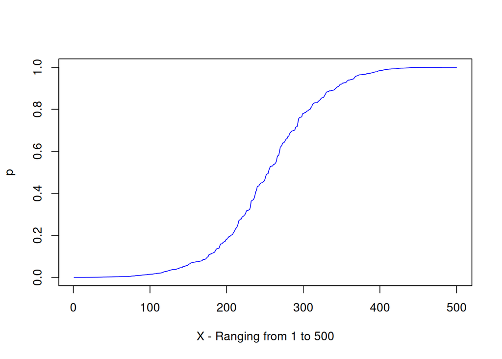

```r
plot(x = seq(1,500), y = p,
     type="l",
     col = "blue",
     xlab="X - Ranging from 1 to 500")
```

- The same equation can be re-written as:
  $$e^Y = \frac{p}{1 - p}$$
- Taking log on both the sides, we get:
  $$Y = log(\frac{p}{1 - p})$$

Therefore, what we are going to model in the logistic regression is:
$$Y = log(\frac{p}{1 - p}) = \beta_0 + \beta_1 X_1 + \beta_2 X_2 + \beta_2
X_3$$

As a linear function of a set of predictive variables X, the above model calculates the probability of success for the outcome variable Y. By including exponential terms from the predictor variables in both the numerator and denominator, the ratio is always positive. In addition, when the exponential term is small, the ratio approaches zero. The ratio increases as the value of the exponential term increases. When the exponential term has a very large value, the ratio approaches one. By doing so, we ensure that the function accurately models that probability. The increase in log odds for a unit increase in X is represented by beta terms. Logistic regression is different from linear regression. The target variable is directly related to the predictor variables in linear regression. A logistic regression takes a probabilistic view of two binary variable outcomes and relates the log odds of one outcome to a linear function of the predictor variables.

```r
admissions <- read.csv(paste0(getwd(),"/UCLA_Student_Admissions.csv"))
summary(admissions)
```

```
##      admit             gre             gpa             rank
##  Min.   :0.0000   Min.   :220.0   Min.   :2.260   Min.   :1.000
##  1st Qu.:0.0000   1st Qu.:520.0   1st Qu.:3.130   1st Qu.:2.000
##  Median :0.0000   Median :580.0   Median :3.395   Median :2.000
##  Mean   :0.3175   Mean   :587.7   Mean   :3.390   Mean   :2.485
##  3rd Qu.:1.0000   3rd Qu.:660.0   3rd Qu.:3.670   3rd Qu.:3.000
##  Max.   :1.0000   Max.   :800.0   Max.   :4.000   Max.   :4.000
```

- From the above summary statistics, we can confirm that there are no missing values in any variable. There are 400 observations in the dataset. The output variable admit (DV) is an integer value.

The output variable has only two possibilities and the frequency can be displayed using the table function. To fit the logistic regression model, this output variable should be a numeric 0 and 1 variable for binary classification. If this is not the case, then the outcome variable should be converted to numeric.

```r
table(admissions$admit)
```

```
##
##   0   1
## 273 127
```

- Setting a seed to a constant value so that the results could be reproducible (However, the reproducibility depends on the R version)

```r
set.seed(1234)
train_test_ind <- sample(c("for_fit", "for_test"), nrow(admissions),
                         replace = T, prob = c(0.80, 0.20))
train <- admissions[train_test_ind == "for_fit",]
test <- admissions[train_test_ind == "for_test",]
```

- Using the train dataset fit a logistic regression

```r
cat_model_logit <- glm(admit ~.,
                       data = train,
                       family = "binomial")
summary(cat_model_logit)
```

```
##
## Call:
## glm(formula = admit ~ ., family = "binomial", data = train)
##
## Coefficients:
##              Estimate Std. Error z value Pr(>|z|)
## (Intercept) -4.511500   1.295752  -3.482 0.000498 ***
## gre          0.001641   0.001215   1.351 0.176840
## gpa          1.161932   0.383170   3.032 0.002426 **
## rank        -0.524750   0.141861  -3.699 0.000216 ***
## ---
## Signif. codes:  0 '***' 0.001 '**' 0.01 '*' 0.05 '.' 0.1 ' ' 1
##
## (Dispersion parameter for binomial family taken to be 1)
##
##     Null deviance: 404.39  on 324  degrees of freedom
## Residual deviance: 370.08  on 321  degrees of freedom
## AIC: 378.08
##
## Number of Fisher Scoring iterations: 3
```

- Let’s pick a single variable, gpa, to understand the model coefficients. gpa is significant at 0.01 alpha value and the coefficient is 1.161932. It is difficult to understand the coefficients in their absolute values.
- Another variable, rank, has four possible values: 1, 2, 3, 4. But, as it is a numeric field they are not captured as multiple level of schools. It should be treated as a factor variable. Re-running the analysis, updated coefficients are captured.

```r
admissions$rank <- factor(admissions$rank)
train <- admissions[train_test_ind == "for_fit",]
test <- admissions[train_test_ind == "for_test",]
cat_model_logit <- glm(admit ~.,
                       data = train,
                       family = "binomial")
summary(cat_model_logit)
```

```
##
## Call:
## glm(formula = admit ~ ., family = "binomial", data = train)
##
## Coefficients:
##              Estimate Std. Error z value Pr(>|z|)
## (Intercept) -5.009514   1.316514  -3.805 0.000142 ***
## gre          0.001631   0.001217   1.340 0.180180
## gpa          1.166408   0.388899   2.999 0.002706 **
## rank2       -0.570976   0.358273  -1.594 0.111005
## rank3       -1.125341   0.383372  -2.935 0.003331 **
## rank4       -1.532942   0.477377  -3.211 0.001322 **
## ---
## Signif. codes:  0 '***' 0.001 '**' 0.01 '*' 0.05 '.' 0.1 ' ' 1
##
## (Dispersion parameter for binomial family taken to be 1)
##
##     Null deviance: 404.39  on 324  degrees of freedom
## Residual deviance: 369.99  on 319  degrees of freedom
## AIC: 381.99
##
## Number of Fisher Scoring iterations: 4
```

- Since those students coming from a high ranked school have higher chances of getting admitted, we can hypothesize that the likelihood of admission decreases from rank 1 schools to rank 4 schools.

#### Looking at the coefficients:

- rank2 -0.570976 0.358273 -1.594 0.111005
- rank3 -1.125341 0.383372 -2.935 0.003331 **
- rank4 -1.532942 0.477377 -3.211 0.001322 **
- Rank 1 school is taken as base.

> All coefficients are negative and become progressively larger in magnitude, indicating that, compared to rank 1, attending a school of rank 2, 3, or 4 lowers the log‑odds of admission. The increasing size of the coefficients from rank 2 to rank 4 reflects a monotonic decrease in admission likelihood as school rank worsens.

> The question of whether to reorder the categories often arises, but in this case the current coding (with rank 1 as the baseline) is perfectly interpretable: the coefficients directly show how each lower rank reduces the log‑odds relative to the top rank. If a different ordering were desired, one could relevel the factor, but it is not necessary for a clear interpretation. Log‑odds provide a straightforward way to quantify these effects.

```r
log_odds <- exp(cat_model_logit$coefficients)
log_odds
```

```
## (Intercept)         gre         gpa       rank2       rank3       rank4
## 0.006674146 1.001632616 3.210441592 0.564973638 0.324541827 0.215899505
```

Interpret the outcome in terms of odds ratio is easy. If rank 1 is considered as base, then the chance of admission drops by a factor of 0.57 for a student coming from rank 2 school.

- Capture the accuracy on the test sample.
- Use the fit model created using the train sameple for making predictions on the test (validation) sample.

```r
predict_test_outcome <- predict(cat_model_logit,
                                    test,
                                    type = "response")

# The predicted outcome is between 0 and 1. If the value is greater than 0.5, it can be considered as 1
predict_test_outcome <- ifelse(predict_test_outcome > 0.5, 1, 0)

# Get the accuracy using the training sample
# First create a confusion matrix or contingency table
confusionMatrix <- table(test$admit, predict_test_outcome)
confusionMatrix <- as.data.frame(confusionMatrix)
colnames(confusionMatrix) <- c("true_outcome",
                               "predicted_outcome",
                               "frequency")
accuracy <- sum(confusionMatrix[
  confusionMatrix$true_outcome == confusionMatrix$predicted_outcome, "frequency"]) /
  sum(confusionMatrix$frequency)
accuracy
```

```
## [1] 0.6933333
```

- Finally, create a visual representation of the confusion matrix (special type of contingency table)

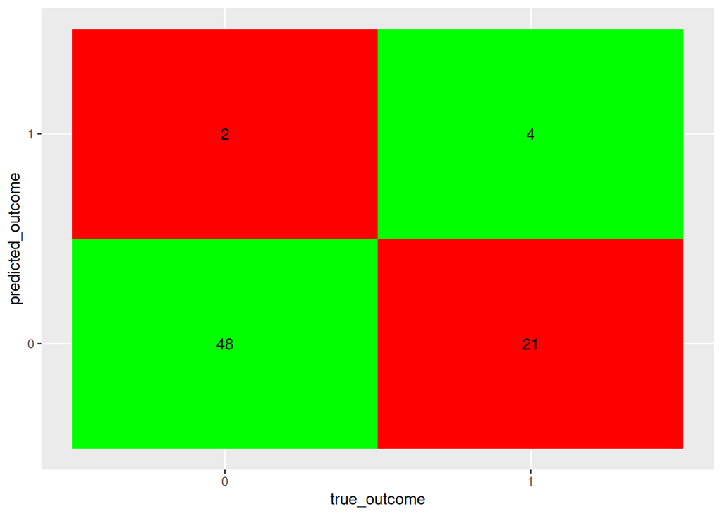

```r
library(ggplot2)
ggplot(data = confusionMatrix, mapping = aes(x = true_outcome, y = predicted_outcome)) +
  geom_tile(fill=c("green", "red", "red", "green")
            ) +
  geom_text(aes(label = frequency))
```

- Type I (Medical trials)
- Type II

False - Positive: 2 True Positives: 4 False Negatives: 21  
True Negatives: 48

Accuracy: (TP + TN) / Total Recall or Sensitivity: TP / (TP + FN) Specificity: TN / (TN + FP)

```r
library(pROC)
predict_test_outcome <- predict(cat_model_logit,
                                    test,
                                    type = "response")

roc_parameters <- multiclass.roc(test$admit, predict_test_outcome, percent = TRUE)
```

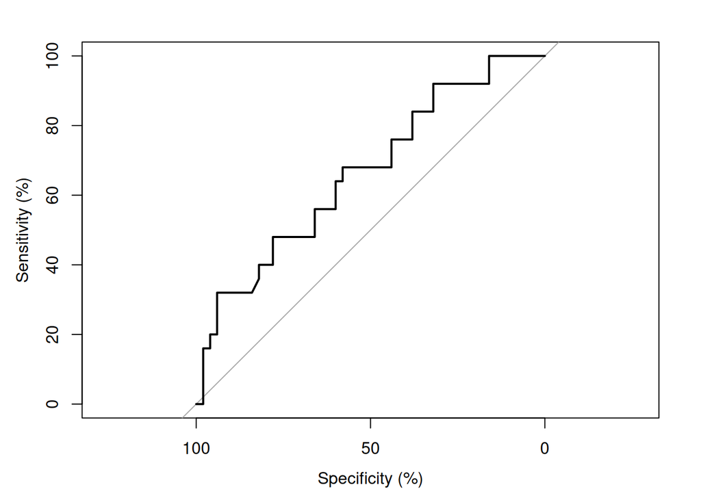

```r
roc <- roc_parameters[["rocs"]][[1]]
plot.roc(roc)
```

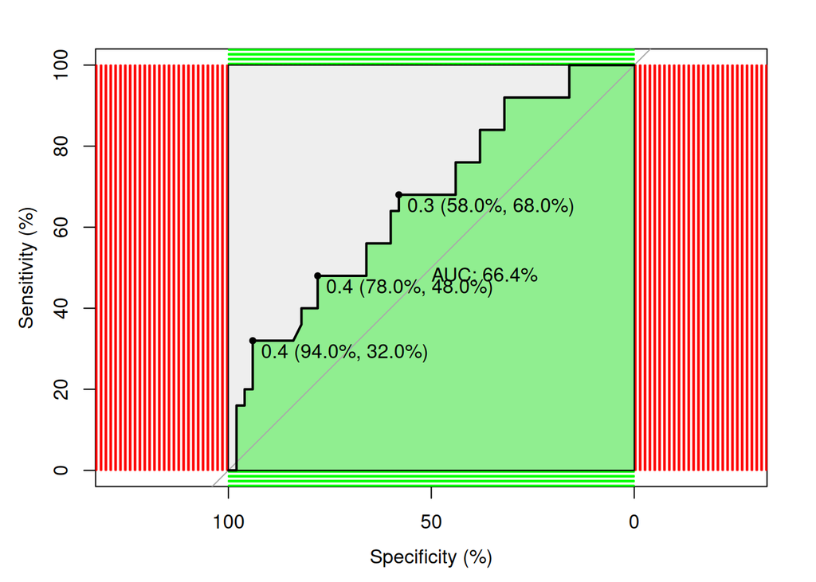

```r
plot.roc(roc,
         print.auc = TRUE,
         grid = c(0.1, 0.1),
         auc.polygon = TRUE,
         print.thres = TRUE,
         auc.polygon.col = "lightgreen",
         max.auc.polygon = T,
         grid.col = c("green", "red")
         )
```

```r
### ?coords()
coords(roc, "best", input="threshold")
```

```
##   threshold specificity sensitivity
## 1 0.2949023          58          68
## 2 0.3647070          78          48
## 3 0.4249419          94          32
```

## ROC Curve Analysis

An **ROC (Receiver Operating Characteristic) curve** is a graph that illustrates the diagnostic ability of a binary classifier system. It helps us to visualize the trade-off between **Sensitivity** and **Specificity** as we change the “threshold” for what counts as a “Yes” (e.g., admitting a student or flagging a stock).

### 1. Understanding the Axes

- **Y-Axis: Sensitivity (True Positive Rate)**: This measures how good the model is at catching the “Yes” cases. In your admissions example, it is the percentage of students who were *actually* admitted that the model correctly predicted would be admitted.
- **X-Axis: Specificity (True Negative Rate)**: This measures how good the model is at catching the “No” cases. Traditionally, the X-axis is plotted as **1 - Specificity** (False Positive Rate), but many tools (including the `pROC` library) allow us to view it as Specificity.

### 2. Explaining the Points

The “points” represented on the ROC curve tell us about the performance of our model at different probability thresholds. In our data, the coordinates are shown as **Threshold (Specificity %, Sensitivity %)**. Let’s look at how the model’s behavior shifts:

[output not shown]

#### Cleaner way to implement logistic regression using tidymodels (Just same dish in new bowl :) )

> **Note:** To broaden the scope of your predictive modeling skills, exploring a variety of algorithms is essential. The **`tidymodels`** framework is particularly powerful here because once you understand the “recipe” and “workflow” structure, you can switch between these complex models by changing only a few lines of code.

```r
# 0. Load Required Libraries
library(tidymodels)
library(pROC) # Still used for certain ROC visualizations
```

```r
# 1. Data Splitting
set.seed(1234)

# Convert 'admit' to a factor with descriptive labels for clarity
admissions$admit <- factor(admissions$admit,
                           levels = c(0, 1),
                           labels = c("Rejected", "Admitted"))

# Now proceed with data split
# create_initial_split ensures the proportion of 'admit' is similar in both sets
set.seed(1234)
data_split <- initial_split(admissions, prop = 0.70, strata = admit)
train_data <- training(data_split)
test_data  <- testing(data_split)
```

```r
# 2. Recipe (Preprocessing)
# We tell R that 'admit' is the outcome and everything else is a predictor
admin_recipe <- recipe(admit ~ ., data = train_data) %>%
  step_dummy(all_nominal_predictors()) %>% # Automatically creates dummy variables for factors
  step_zv(all_predictors())               # Removes variables with zero variance which are like same value in all rows
```

```r
# 3. Model Specification
# Define the "What" and the "How"
lr_spec <- logistic_reg() %>%
  set_engine("glm") %>%
  set_mode("classification")
```

```r
# 4. Create the Workflow
# This "packages" the recipe and the model together
admin_wflow <- workflow() %>%
  add_recipe(admin_recipe) %>%
  add_model(lr_spec)
```

```r
# 5. Model Training (The "Fit")
admin_fit <- admin_wflow %>%
  fit(data = train_data)
```

```r
# 6. Prediction and Evaluation
# Collect predictions on the test set
results <- test_data %>%
  select(admit) %>%
  bind_cols(predict(admin_fit, test_data, type = "prob")) %>%
  bind_cols(predict(admin_fit, test_data, type = "class"))
```

```r
# 7. Metrics (The "Leaderboard")
# accuracy and kap use the 'estimate' (the class)
# roc_auc uses the '.pred_Admitted' (the probability)
admission_metrics <- metric_set(yardstick::accuracy,
                                yardstick::kap,
                                yardstick::roc_auc)

# Calculate the metrics
metrics_results <- results %>%
  admission_metrics(truth = admit,
                    estimate = .pred_class,
                    .pred_Admitted,
                    event_level = "second")

print(metrics_results)
```

```
## # A tibble: 3 × 3
##   .metric  .estimator .estimate
##   <chr>    <chr>          <dbl>
## 1 accuracy binary         0.694
## 2 kap      binary         0.210
## 3 roc_auc  binary         0.629
```

```r
# 8. ROC Curve Visualization
#results %>%
#  roc_curve(truth = admit, .pred_Admitted) %>%
#  autoplot()
```

```r
# We use results$admit as the truth and results$.pred_Admitted as the probability
roc_obj <- roc(results$admit, results$.pred_Admitted, percent = TRUE)
```

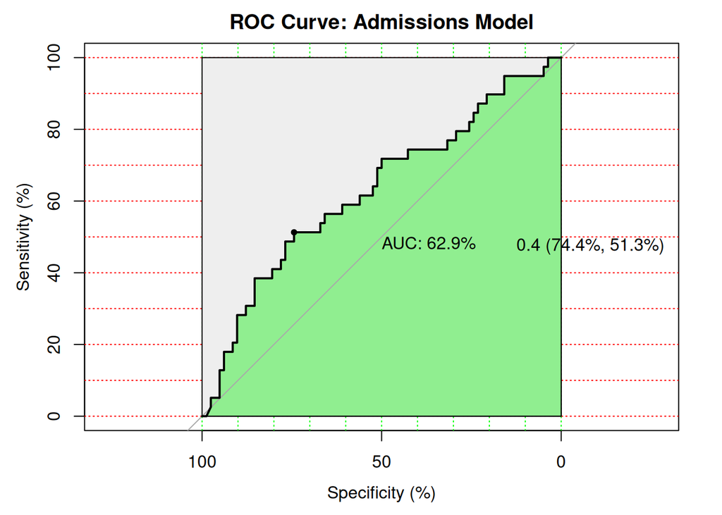

```r
# 2. Plot with Specificity on the X-Axis and custom colors
plot.roc(roc_obj,
         legacy.axes = FALSE,      # This shows Specificity instead of 1-Specificity
         print.auc = TRUE,
         grid = c(10, 10),         # Adds the grid lines
         auc.polygon = TRUE,
         auc.polygon.col = "lightgreen",
         max.auc.polygon = TRUE,
         print.thres = TRUE,       # Displays the 'best' threshold point
         print.thres.adj = c(-1.5, 1.5),
         grid.col = c("green", "red"),
         main = "ROC Curve: Admissions Model")
```

## Expanding Your Modeling Toolkit

To broaden the scope of your predictive modeling skills, exploring a variety of algorithms is essential. Below are the most important models to explore, categorized by task type.

### 1. Regression Models (Predicting Continuous Values)

Beyond standard Linear, Ridge, and Lasso regression, these models handle non-linear relationships and complex interactions more effectively.

#### Random Forest Regression (`rand_forest`)

- **Concept**: An ensemble method that builds multiple decision trees and averages their predictions. It is excellent for handling outliers and non-linear data without requiring scaling.
- **Implementation**: Use the `ranger` engine.

#### Boosted Trees (XGBoost/LightGBM) (`boost_tree`)

- **Concept**: Like Random Forest, but builds trees sequentially, where each new tree corrects the errors of the previous ones. This is currently the “gold standard” for winning data science competitions.
- **Implementation**: Use the `xgboost` engine.

#### K-Nearest Neighbors (KNN) (`nearest_neighbor`)

- **Concept**: Predicts the value of a data point by averaging the values of the “K” most similar points in the training set.
- **Note**: Requires `step_normalize()` in the recipe, as it is distance-based.

### 2. Classification Models (Predicting Categories)

While Logistic Regression is the baseline, these models often provide higher accuracy for complex datasets like the stock market movement prediction.

#### Random Forest Classification (`rand_forest`)

- **Concept**: Instead of averaging (like in regression), the trees “vote” on the final class. It is highly robust against overfitting.

#### Naïve Bayes (`naive_Bayes`)

- **Concept**: Based on Bayes’ Theorem, it assumes predictors are independent. It is incredibly fast and works surprisingly well for text classification and high-dimensional data.
- **Implementation**: Use the `discrim` library engine.

#### Support Vector Machines (SVM) (`svm_rbf`)

- **Concept**: Finds the “widest street” (margin) between classes. The Radial Basis Function (RBF) kernel is particularly good at finding circular or complex boundaries.

#### Decision Trees (`decision_tree`)

- **Concept**: A simple, highly interpretable model that splits data into branches based on “if-then” logic. It is great for visualizing the “rules” the model uses to make a choice.